# RTL-Arrow

Hardware-to-Cloud Bridge

Calvin Deutschbein, Jimmy Ostler

# Motivation

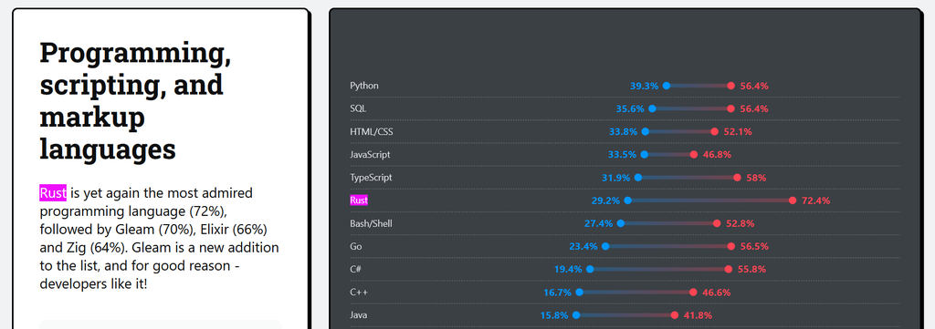

- Stack Overflow Annual Developer Survey, 2025

## Problem Statement

- The end of MOSFET scaling leads to dedicated silicon for most tasks:
  - Designs are more complex, and
  - Automated design is more powerful.
- An explosion of hardware complexity drove major advances in Hardware Design Languages (HDLs).
- Post-2010 advances in program language thoery are essentially unused in hardware design.

## Take Hardware Traces

- `c1.clk` (denoted `"`) changes to value `1` at time `#3`.

```
test.vcd
```

```
$scope module test $end
$var wire 4 ! val [3:0] $end
$var reg 1 " clk $end
$var reg 1 # rst $end
$scope module c1 $end
$var wire 1 " clk $end
$var wire 1 # rst $end
$var reg 4 $ out [3:0] $end
$upscope $end
$upscope $end
$enddefinitions $end
```

```
test.vcd
```

```
#0
$dumpvars
bx $
0#
0"
bx !
$end
#1
b0 !
b0 $
1"
#2
0"
#3
1"
#4
0"
#5
b1 !
b1 $
1"
1#
#6
0"
#7
b10 !
b10 $
1"
#8
0"
#9
b11 !
b11 $
1"
```

## Dataframe

- We can view this as a dataframe!

```bash
$ pip install vcd2df
$ python3 -c "import vcd2df as v; print(v.vcd2df('test.vcd'))"
     #0  #1  #2  #3  #4  #5  #6  #7  #8
val  -1   0   0   0   0   1   1   2   2
clk   0   1   0   1   0   1   0   1   0
rst   0   0   0   0   0   1   1   1   1
out  -1   0   0   0   0   1   1   2   2
```

- In the Python implementation `-1` denotes an *uninitialized* (not yet set) register.
- Wait - isn’t that terrible?
  - Now we need an additional sign bit!

## Our Insight

- When first implemented, early DataFrame libraries like **pandas** often used float `NaN` to denote invalid entiries.
- However, new and better technologies exist:
  - Within cloud technologies, Arrow formats support *nullable columns*
  - Within programing languages, Rust supports the `Option` type.

## Arrow

> [All array types, with the exception of union types (more on these later), utilize a dedicated memory buffer, known as the validity (or “null”) bitmap, to encode the nullness or non-nullness of each value slot.](https://arrow.apache.org/docs/format/Columnar.html#validity-bitmaps)

```c
is_valid[j] -> bitmap[j / 8] & (1 << (j % 8))
```

- An example:

```
values = [0, 1, null, 2, null, 3]

bitmap
j mod 8   7  6  5  4  3  2  1  0
          0  0  1  0  1  0  1  1
```

## Rust

> Type `Option` represents an optional value: every `Option` is either `Some` and contains a value, or `None`, and does not.

```rust
// Pattern match to retrieve the value
match result {
    // The operation was valid
    Some(x) => println!("Result: {x}"),
    // The operation was invalid
    None    => println!("Invalid operation!"),
}
```

## Viola!

```bash
┌───────┬──────┬─────┬─────┬───┬─────┬─────┬─────┬─────┐
│ Names ┆ #0   ┆ #1  ┆ #2  ┆ … ┆ #6  ┆ #7  ┆ #8  ┆ #9  │
│ ---   ┆ ---  ┆ --- ┆ --- ┆   ┆ --- ┆ --- ┆ --- ┆ --- │
│ str   ┆ u64  ┆ u64 ┆ u64 ┆   ┆ u64 ┆ u64 ┆ u64 ┆ u64 │
╞═══════╪══════╪═════╪═════╪═══╪═════╪═════╪═════╪═════╡
│ val   ┆ null ┆ 0   ┆ 0   ┆ … ┆ 1   ┆ 2   ┆ 2   ┆ 3   │
│ clk   ┆ 0    ┆ 1   ┆ 0   ┆ … ┆ 0   ┆ 1   ┆ 0   ┆ 1   │
│ rst   ┆ 0    ┆ 0   ┆ 0   ┆ … ┆ 1   ┆ 1   ┆ 1   ┆ 1   │
│ out   ┆ null ┆ 0   ┆ 0   ┆ … ┆ 1   ┆ 2   ┆ 2   ┆ 3   │
└───────┴──────┴─────┴─────┴───┴─────┴─────┴─────┴─────┘
```

- All those `-1`’s that don’t make sense are now an Arrow `null` by way of a Rust `None`!

## Setup

- We compared vs. Python on 3 metrics
  - Build time
  - Container size
  - Runtime

> To do so, we implemented a crate in Rust and performed a simple example, based on a use case involving a map of information flow detection across 181 value change dump files.

## Architecture

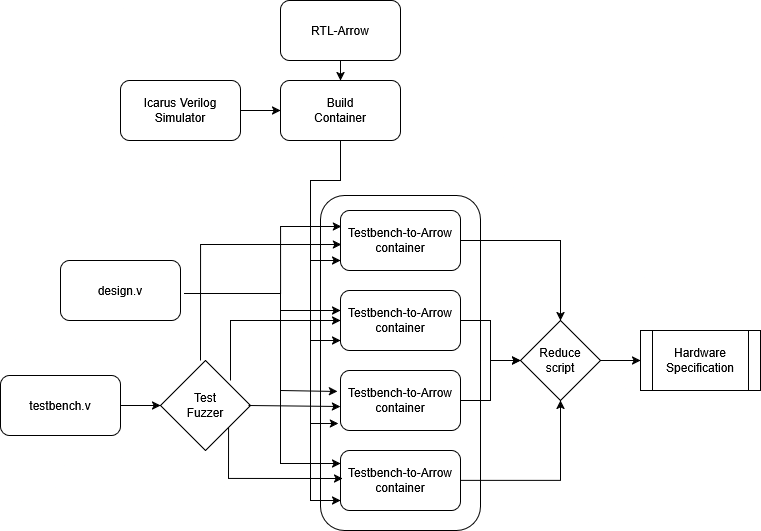

## Build Time

- We created separate *build* and *cluster* containers
- **Python**: installing the relevant runtime on a cluster container
- **Rust**: installing the compiler toolchain on the build container, compiling, and copying an executable to the cluster container.

| Python | Rust |
| --- | --- |
| 74.5s | 291.7s |

## Container Size

- We created separate *build* and *cluster* containers
- **Python**: Repurposed the build container.
- **Rust**: We report the sizes separately as “Build” and “Cluster”

| Python | Build | Cluster |
| --- | --- | --- |
| 1.76 GB | 2.59 GB | .78 GB |

## Run Time

- Extract a security specification over a ~65 MB data set.

| Python | Rust |
| --- | --- |
| 28.5s | 2.2s |

> We found this performance unexpectedly high. Having specifically worked in Python for this research direction for close to a decade, we have few remaining optimizations… By contrast, we… were concerned a lack of familiarity with the language may incur heavy costs due to unnecessary borrows or poor choice of types.

# Summary

- Leverage cloud and language advances for encoding.
- No need for specialized tools (e.g. waveform viewers).
- Package traces easily into Parquet to parallelize.
- Reproducability
  - All resources via GitHub: github.com/vcd2df/pnsqc